# Class11: RNA-Seq continued

Sam Altshuler (PID: A59010373)

2/23/2022

# Transcriptomics and Analysis of RNA-Seq Data

Today we will run differential expression analysis of published data from Himes et al.

## Import the countData and colData

```r
counts <- read.csv("airway_scaledcounts.csv", row.names = 1)
metadata <- read.csv("airway_metadata.csv")
```

```r
head(counts)
```

```
##                 SRR1039508 SRR1039509 SRR1039512 SRR1039513 SRR1039516
## ENSG00000000003        723        486        904        445       1170
## ENSG00000000005          0          0          0          0          0
## ENSG00000000419        467        523        616        371        582
## ENSG00000000457        347        258        364        237        318
## ENSG00000000460         96         81         73         66        118
## ENSG00000000938          0          0          1          0          2
##                 SRR1039517 SRR1039520 SRR1039521
## ENSG00000000003       1097        806        604
## ENSG00000000005          0          0          0
## ENSG00000000419        781        417        509
## ENSG00000000457        447        330        324
## ENSG00000000460         94        102         74
## ENSG00000000938          0          0          0
```

There are 38694 rows, i.e. “genes” in this dataset. There are 8 columns in this dataset, i.e. experiments in the dataset.

```r
metadata
```

```
##           id     dex celltype     geo_id
## 1 SRR1039508 control   N61311 GSM1275862
## 2 SRR1039509 treated   N61311 GSM1275863
## 3 SRR1039512 control  N052611 GSM1275866
## 4 SRR1039513 treated  N052611 GSM1275867
## 5 SRR1039516 control  N080611 GSM1275870
## 6 SRR1039517 treated  N080611 GSM1275871
## 7 SRR1039520 control  N061011 GSM1275874
## 8 SRR1039521 treated  N061011 GSM1275875
```

The rows in the metadata set corresponds to the experiments being run (the columns in the counts dataset). There are 4 controls and 4 treated experiments.

The next question is does the drug do anything?

First confirm that the metadata matches the counts data.

```r
#column names of counts compared to ID column of metadata
all(colnames(counts) == metadata$id)
```

```
## [1] TRUE
```

All of the data names match up!

Gather all of the control data (extract from metadata).

```r
#Store the IDs of the control experiments
control <- metadata[metadata$dex == "control", "id"]
# Pull the columns corresponding to the controls from the counts dataset
ct_control <- counts[,control]
```

Gather all of the treated data. This is the same as above but for the treated columns.

```r
treat <- metadata[metadata$dex == "treated", "id"]
ct_treat <- counts[,treat]
```

Get a mean gene expression per gene for both the control and the treated. Use `apply()` or `rowMeans()`.

```r
# using apply: apply(ct_control, 1, mean)
control.mean <- rowMeans(ct_control)
treated.mean <- rowMeans(ct_treat)
```

Compare the two experimental conditions in a plot.

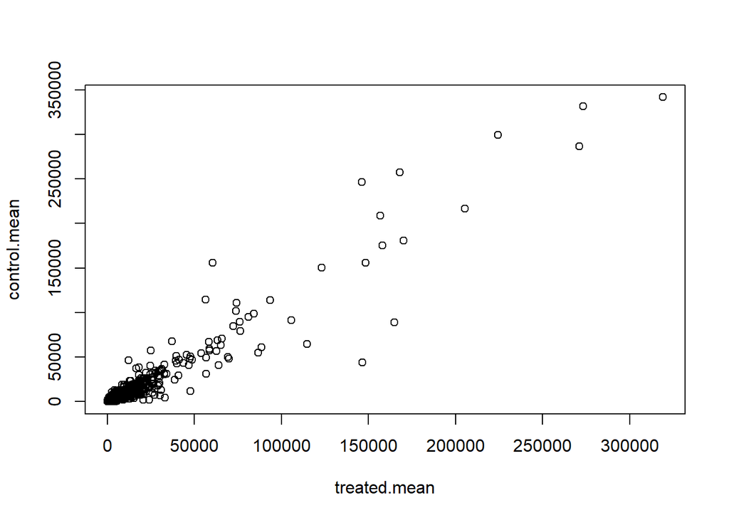

```r
plot(treated.mean, control.mean)
```

There are a bunch of genes with low values that overlap, making it hard to ID individual genes. The data is very skewed. The solution is to transform the data (like a log transformation) to make it more readable especially around overlapping values.

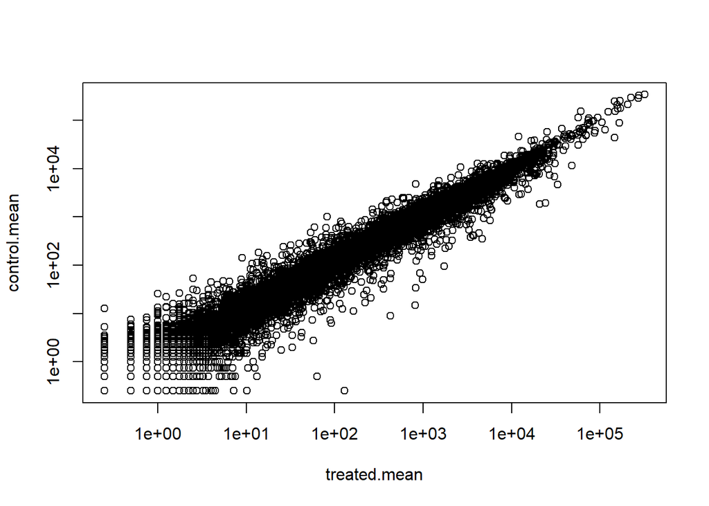

```r
plot(treated.mean, control.mean, log = "yx")
```

We need to get rid of zeros because you can’t take a log of 0.

We often use log 2 transformation because it has an easier to understand output. A log 2 value of zero means that there’s been no change (lies on the straight line). A value of 1 means it’s doubled from treatment compared to control and -1 means it’s half. This is called the fold change (how much is it doubling)

```r
log2fc <- log2(treated.mean/control.mean)
```

Make a dataframe to store the results

```r
ct_mean <- data.frame(control.mean, treated.mean, log2fc)
head(ct_mean)
```

```
##                 control.mean treated.mean      log2fc
## ENSG00000000003       900.75       658.00 -0.45303916
## ENSG00000000005         0.00         0.00         NaN
## ENSG00000000419       520.50       546.00  0.06900279
## ENSG00000000457       339.75       316.50 -0.10226805
## ENSG00000000460        97.25        78.75 -0.30441833
## ENSG00000000938         0.75         0.00        -Inf
```

Try to find and filter out the zero values.

```r
# Choose all count values for both control and treated with a value of zero
# make sure to return array indices where in the dataframe the zero values are
# Save the rows that correspond to the zero values
zip <- unique(which(ct_mean[,1:2] == 0, arr.ind = TRUE)[,"row"])
# Remove the rows that correspond to zero values from the dataframe
ct_mean_2 <- ct_mean[-zip,]
head(ct_mean_2)
```

```
##                 control.mean treated.mean      log2fc
## ENSG00000000003       900.75       658.00 -0.45303916
## ENSG00000000419       520.50       546.00  0.06900279
## ENSG00000000457       339.75       316.50 -0.10226805
## ENSG00000000460        97.25        78.75 -0.30441833
## ENSG00000000971      5219.00      6687.50  0.35769358
## ENSG00000001036      2327.00      1785.75 -0.38194109
```

There are 21817 genes left after removing the zero values.

There are 250 genes that have a log2fc more than +2 (upregulated).

```r
sum(ct_mean_2$log2fc > 2)
```

```
## [1] 250
```

These log2fc may not actually be statistically significant. Time to use the DESeq2 package!

# DESeq2

```r
library(DESeq2)
```

First we need to set up the DESeq data object.

```r
dds <- DESeqDataSetFromMatrix(countData=counts,
                              colData=metadata,
                              design=~dex)
dds
```

```
## class: DESeqDataSet
## dim: 38694 8
## metadata(1): version
## assays(1): counts
## rownames(38694): ENSG00000000003 ENSG00000000005 ... ENSG00000283120
##   ENSG00000283123
## rowData names(0):
## colnames(8): SRR1039508 SRR1039509 ... SRR1039520 SRR1039521
## colData names(4): id dex celltype geo_id
```

```r
dds <- DESeq(dds)
res <- results(dds)
res
```

```
## log2 fold change (MLE): dex treated vs control
## Wald test p-value: dex treated vs control
## DataFrame with 38694 rows and 6 columns
##                  baseMean log2FoldChange     lfcSE      stat    pvalue
##                 <numeric>      <numeric> <numeric> <numeric> <numeric>
## ENSG00000000003  747.1942     -0.3507030  0.168246 -2.084470 0.0371175
## ENSG00000000005    0.0000             NA        NA        NA        NA
## ENSG00000000419  520.1342      0.2061078  0.101059  2.039475 0.0414026
## ENSG00000000457  322.6648      0.0245269  0.145145  0.168982 0.8658106
## ENSG00000000460   87.6826     -0.1471420  0.257007 -0.572521 0.5669691
## ...                   ...            ...       ...       ...       ...
## ENSG00000283115  0.000000             NA        NA        NA        NA
## ENSG00000283116  0.000000             NA        NA        NA        NA
## ENSG00000283119  0.000000             NA        NA        NA        NA
## ENSG00000283120  0.974916      -0.668258   1.69456 -0.394354  0.693319
## ENSG00000283123  0.000000             NA        NA        NA        NA
##                      padj
##                 <numeric>
## ENSG00000000003  0.163035
## ENSG00000000005        NA
## ENSG00000000419  0.176032
## ENSG00000000457  0.961694
## ENSG00000000460  0.815849
## ...                   ...
## ENSG00000283115        NA
## ENSG00000283116        NA
## ENSG00000283119        NA
## ENSG00000283120        NA
## ENSG00000283123        NA
```

`padj` is the adjusted p-value for multiple testing.

## A main results figure

A common main results figur is a volcano plot. This is a plot of the log2 fold change on the x axis v the p-value (or padj) on the y-axis.

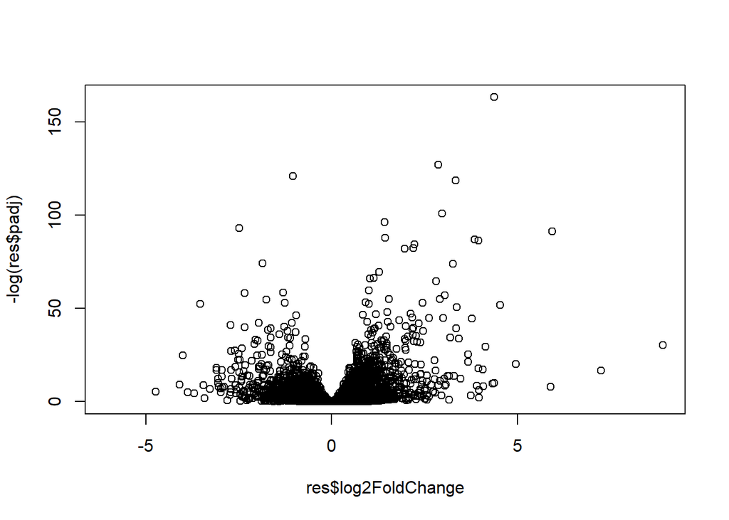

```r
plot(res$log2FoldChange, -log(res$padj))
```

As it goes up the y-axis, the smaller the p-value, the less likely the fold change is due to random chance (i.e. false positivess). The plot function should be `plot(foldchange, -log(p-value))`.

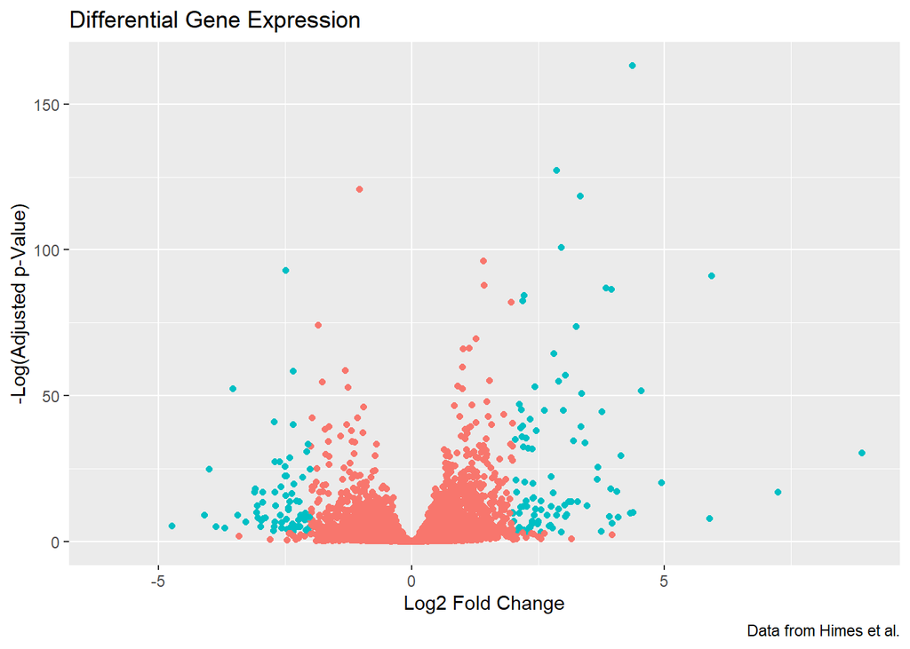

```r
library(ggplot2)
# make the same volcano plot as above but color by if the p value is less than 0.05 AND
# the log2 fold change is greater than 2 or less than -2 (absolute value is greater than 2)
ggplot(as.data.frame(res))+
  aes(x = log2FoldChange, y = -log(padj), color = padj < 0.05 & abs(log2FoldChange) > 2)+
  geom_point()+
  xlab("Log2 Fold Change") +
  ylab("-Log(Adjusted p-Value)")+
  labs(title = "Differential Gene Expression", caption = "Data from Himes et al.")+
  theme(legend.position = "none")
```

# Add Annotation Data

We need to get the gene names in a format we can understand.

We need `BiocManager::install("AnnotationDbi")` and `BiocManager::install("org.Hs.eg.db")`.

```r
library(AnnotationDbi)
library(org.Hs.eg.db)
```

Now we can use the `mapIDs()` function from the AnnotationDbi package to find the aliases of the genes of interest.

```r
#First we look at what is available to map between
columns(org.Hs.eg.db)
```

```
##  [1] "ACCNUM"       "ALIAS"        "ENSEMBL"      "ENSEMBLPROT"  "ENSEMBLTRANS"
##  [6] "ENTREZID"     "ENZYME"       "EVIDENCE"     "EVIDENCEALL"  "GENENAME"
## [11] "GENETYPE"     "GO"           "GOALL"        "IPI"          "MAP"
## [16] "OMIM"         "ONTOLOGY"     "ONTOLOGYALL"  "PATH"         "PFAM"
## [21] "PMID"         "PROSITE"      "REFSEQ"       "SYMBOL"       "UCSCKG"
## [26] "UNIPROT"
```

```r
#Store the correctly mapped IDs as a column in the results data frame
res$symbol <- mapIds(org.Hs.eg.db,
                     key = row.names(res), # what are the values you are trying to map
                     keytype = "ENSEMBL", # what is the format of the values
                     column = "SYMBOL", # what are we mapping two
                     multiVals = "first") # if there are multiple values in the symbol, choose the first value
res$gene_name <- mapIds(org.Hs.eg.db,
                     key = row.names(res),
                     keytype = "ENSEMBL",
                     column = "GENENAME",
                     multiVals = "first")
res$entrez <- mapIds(org.Hs.eg.db,
                     key = row.names(res),
                     keytype = "ENSEMBL",
                     column = "ENTREZID",
                     multiVals = "first")
#Check the results data frame to confirm that the columns were added correctly
head(res)
```

```
## log2 fold change (MLE): dex treated vs control
## Wald test p-value: dex treated vs control
## DataFrame with 6 rows and 9 columns
##                   baseMean log2FoldChange     lfcSE      stat    pvalue
##                  <numeric>      <numeric> <numeric> <numeric> <numeric>
## ENSG00000000003 747.194195     -0.3507030  0.168246 -2.084470 0.0371175
## ENSG00000000005   0.000000             NA        NA        NA        NA
## ENSG00000000419 520.134160      0.2061078  0.101059  2.039475 0.0414026
## ENSG00000000457 322.664844      0.0245269  0.145145  0.168982 0.8658106
## ENSG00000000460  87.682625     -0.1471420  0.257007 -0.572521 0.5669691
## ENSG00000000938   0.319167     -1.7322890  3.493601 -0.495846 0.6200029
##                      padj      symbol              gene_name      entrez
##                 <numeric> <character>            <character> <character>
## ENSG00000000003  0.163035      TSPAN6          tetraspanin 6        7105
## ENSG00000000005        NA        TNMD            tenomodulin       64102
## ENSG00000000419  0.176032        DPM1 dolichyl-phosphate m..        8813
## ENSG00000000457  0.961694       SCYL3 SCY1 like pseudokina..       57147
## ENSG00000000460  0.815849    C1orf112 chromosome 1 open re..       55732
## ENSG00000000938        NA         FGR FGR proto-oncogene, ..        2268
```

# Pathway Analysis (geneset enrichment)

Load up some more packages

```r
library(pathview)
library(gage)
library(gageData)


data(kegg.sets.hs)

# Examine the first 2 pathways in this kegg set for humans
head(kegg.sets.hs, 2)
```

```
## $`hsa00232 Caffeine metabolism`
## [1] "10"   "1544" "1548" "1549" "1553" "7498" "9"
##
## $`hsa00983 Drug metabolism - other enzymes`
##  [1] "10"     "1066"   "10720"  "10941"  "151531" "1548"   "1549"   "1551"
##  [9] "1553"   "1576"   "1577"   "1806"   "1807"   "1890"   "221223" "2990"
## [17] "3251"   "3614"   "3615"   "3704"   "51733"  "54490"  "54575"  "54576"
## [25] "54577"  "54578"  "54579"  "54600"  "54657"  "54658"  "54659"  "54963"
## [33] "574537" "64816"  "7083"   "7084"   "7172"   "7363"   "7364"   "7365"
## [41] "7366"   "7367"   "7371"   "7372"   "7378"   "7498"   "79799"  "83549"
## [49] "8824"   "8833"   "9"      "978"
```

The `gage()` function requires a vector of fold changes. The names are the entrezIDs for the genes.

```r
foldchanges <- res$log2FoldChange
# Give each position in the vector a name (the correct entrezID for the foldchange values)
# This allows for easier indexing when you know what each position is actually IDed as
names(foldchanges) <- res$entrez
head(foldchanges)
```

```
##        7105       64102        8813       57147       55732        2268
## -0.35070302          NA  0.20610777  0.02452695 -0.14714205 -1.73228897
```

Now let’s run the geneset enrichment (AKA pathway analysis).

```r
# Get the results
keggres <- gage(foldchanges, gsets=kegg.sets.hs)

#look at what is in this new object using the attributes function
attributes(keggres)
```

```
## $names
## [1] "greater" "less"    "stats"
```

The keggres object is split into three lists: `$greater` (up), `$less` (down), and `$stats`.

Let’s look at the “less” list of pathways.

```r
head(keggres$less, 3)
```

```
##                                       p.geomean stat.mean        p.val
## hsa05332 Graft-versus-host disease 0.0004250461 -3.473346 0.0004250461
## hsa04940 Type I diabetes mellitus  0.0017820293 -3.002352 0.0017820293
## hsa05310 Asthma                    0.0020045888 -3.009050 0.0020045888
##                                         q.val set.size         exp1
## hsa05332 Graft-versus-host disease 0.09053483       40 0.0004250461
## hsa04940 Type I diabetes mellitus  0.14232581       42 0.0017820293
## hsa05310 Asthma                    0.14232581       29 0.0020045888
```

Let’s explore the Asthma path a bit closer.

```r
pathview(gene.data=foldchanges, pathway.id="hsa05310")
```

```
## Info: Working in directory C:/Users/16515/Documents/Documents/UCSD/Foundations of Bioinformatics/Lab11
```

```
## Info: Writing image file hsa05310.pathview.png
```

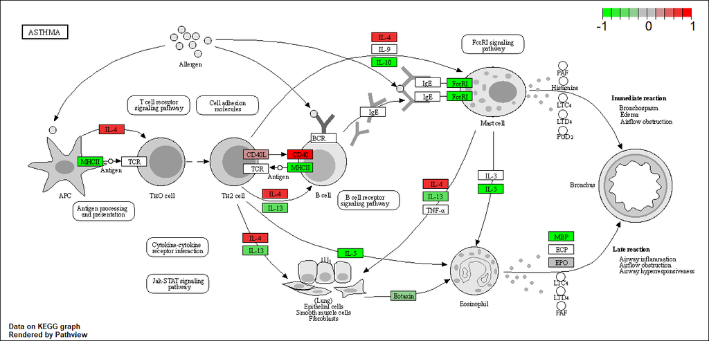